# **Analisis de Componentes Principales (PCA)**

**PCA con datos de Macrófagos en el Microambiente Tumoral (TME): análisis y visualización.**

Este ejemplo explorará un conjunto de datos de expresión obtenidos por RNAseq bulk, a partir de macrófagos entrenados por el TME. Lo primero que debemos hacer es instalar y activar las librerías necesarias para realizar nuestro análisis y su visualización. Para ello debemos ejecutar:

```r
# Instlación y activación de librerías
#install.packages("corrr")
library(corrr)
#install.packages("ggplot2")
library(ggplot2)
#install.packages("ggcorrplot")
library(ggcorrplot)
#install.packages("FactoMineR")
library(FactoMineR)
#install.packages("factoextra")
library(factoextra)
```

- Nota: en R el signo “#” se usa para comentar una línea de código, así el programa no buscará interpretarla, entonces la ignorará. **Es importante establecer su directorio de trabajo.**

Procedemos a cargar nuestro conjunto de datos a trabajar:

```r
# Importacion de datos
# Establcer directorio de trabajo
setwd("D:/marval_windows/JR_MARVAL/programacion/ciencia_computacional_himfg")
list.files()
```

```
[1] "expresion_normalizada_mediana_GMCSF_vs_MACcoCC.csv"
[2] "pca_cc_him.Rmd"
[3] "pca_cienciacomputacional_him.Rmd"
[4] "pcaf_mediana_MACcoCC.png"
```

```r
# Cargar datos
data <- read.table(file = "expresion_normalizada_mediana_GMCSF_vs_MACcoCC.csv", sep = ",",
                   head=T, row.names = 1)
head(data)
```

|  | GMCSF | MCF7 | T47D | MDA.MB.231 | UIVC1 | UIVC4 |
| --- | --- | --- | --- | --- | --- | --- |
| 49 | 0.9502389 | 0.9593455 | 2.363160 | 1.0437782 | 0.9609396 | 1.0038997 |
| 54 | 0.9624568 | 0.4775665 | 0.946373 | 0.5200298 | 0.4721179 | 0.0000000 |
| 68 | 0.4755821 | 0.0000000 | 0.000000 | 1.0400595 | 1.9218793 | 0.9935663 |
| 154 | 10.4774191 | 11.4656981 | 12.872186 | 15.1411591 | 10.5712235 | 19.3256738 |
| 155 | 88.5456735 | 75.9583177 | 87.738063 | 97.1114046 | 78.7970511 | 108.0299034 |
| 156 | 259.3819283 | 230.2634168 | 258.417912 | 332.0583513 | 239.2748595 | 351.1663179 |

```r
# Obtener dimensiones
dimensiones <- dim(data)
dimensiones
```

```
[1] 23872     6
```

Ahora debemos estrucutrar los datos de la forma adecuda para nuestro análisis. También es muy importante **trabajar con datos normalizados**:

```r
# Analisis
# Estructura de datos y búsqueda de valores faltantes
str(data)
```

```
'data.frame':   23872 obs. of  6 variables:
 $ GMCSF     : num  0.95 0.962 0.476 10.477 88.546 ...
 $ MCF7      : num  0.959 0.478 0 11.466 75.958 ...
 $ T47D      : num  2.363 0.946 0 12.872 87.738 ...
 $ MDA.MB.231: num  1.04 0.52 1.04 15.14 97.11 ...
 $ UIVC1     : num  0.961 0.472 1.922 10.571 78.797 ...
 $ UIVC4     : num  1.004 0 0.994 19.326 108.03 ...
```

```r
colSums(is.na(data))
```

```
     GMCSF       MCF7       T47D MDA.MB.231      UIVC1      UIVC4
         0          0          0          0          0          0
```

```r
# Eliminar filas cuya suma sea 0 (uso de las medianas)
data <- data[!(rowSums(data[, -1]) == 0), ]
head(data)
```

|  | GMCSF | MCF7 | T47D | MDA.MB.231 | UIVC1 | UIVC4 |
| --- | --- | --- | --- | --- | --- | --- |
| 49 | 0.9502389 | 0.9593455 | 2.363160 | 1.0437782 | 0.9609396 | 1.0038997 |
| 54 | 0.9624568 | 0.4775665 | 0.946373 | 0.5200298 | 0.4721179 | 0.0000000 |
| 68 | 0.4755821 | 0.0000000 | 0.000000 | 1.0400595 | 1.9218793 | 0.9935663 |
| 154 | 10.4774191 | 11.4656981 | 12.872186 | 15.1411591 | 10.5712235 | 19.3256738 |
| 155 | 88.5456735 | 75.9583177 | 87.738063 | 97.1114046 | 78.7970511 | 108.0299034 |
| 156 | 259.3819283 | 230.2634168 | 258.417912 | 332.0583513 | 239.2748595 | 351.1663179 |

```r
colnames(data)
```

```
[1] "GMCSF"      "MCF7"       "T47D"       "MDA.MB.231" "UIVC1"
[6] "UIVC4"
```

```r
# Obtener dimensiones
dimensiones <- dim(data)
dimensiones
```

```
[1] 21586     6
```

```r
# Normalizar datos
data_nor <- scale(data)
head(data_nor)
```

```
          GMCSF        MCF7        T47D  MDA.MB.231       UIVC1
49  -0.11800757 -0.10787349 -0.09640958 -0.09239659 -0.10372265
54  -0.11790391 -0.11139720 -0.10669071 -0.09537230 -0.10718709
68  -0.12203450 -0.11489010 -0.11355821 -0.09241772 -0.09691215
154 -0.03718014 -0.03103053 -0.02014922 -0.01230130 -0.03561143
155  0.62514134  0.44066542  0.52312650  0.45341856  0.44792729
156  2.07449514  1.56924557  1.76169101  1.78828660  1.58528590
          UIVC4
49  -0.09407694
54  -0.10010890
68  -0.09413903
154  0.01600988
155  0.54899137
156  2.00988235
```

Si observamos la salida del objeto *dimensiones* veremos que disminuye, esto porque eliminamos aquellos genes (filas) en los cuales la suma de sus observaciones es igual a 0. No nos interesa conservar filas de genes que no tienen expresión.

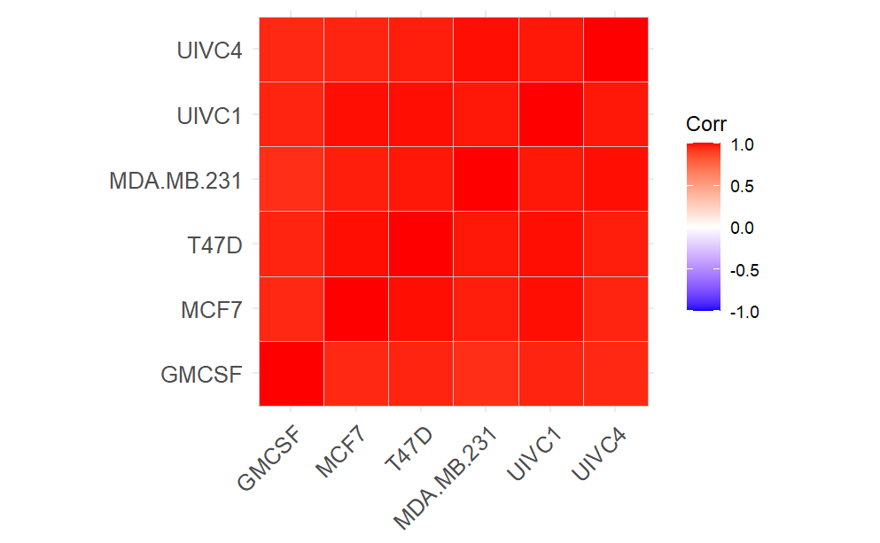

```r
# Matriz de correlacion
corr_matrix <- cor(data_nor)
ggcorrplot(corr_matrix)
```

En este paso se propiamente se hace el PCA. Cada componente explica un porcentaje de la varianza total en el conjunto de datos. El siguiente gráfico nos permite observar la aportación de cada componente a la variación de los datos.

```r
# PCA
pca <- princomp(corr_matrix)
res <- summary(pca)
res
```

```
Importance of components:
                           Comp.1     Comp.2      Comp.3      Comp.4
Standard deviation     0.03541279 0.02179641 0.008605544 0.003130669
Proportion of Variance 0.69025762 0.26149359 0.040761262 0.005394673
Cumulative Proportion  0.69025762 0.95175121 0.992512471 0.997907145
                            Comp.5       Comp.6
Standard deviation     0.001949953 3.785244e-10
Proportion of Variance 0.002092855 7.886396e-17
Cumulative Proportion  1.000000000 1.000000e+00
```

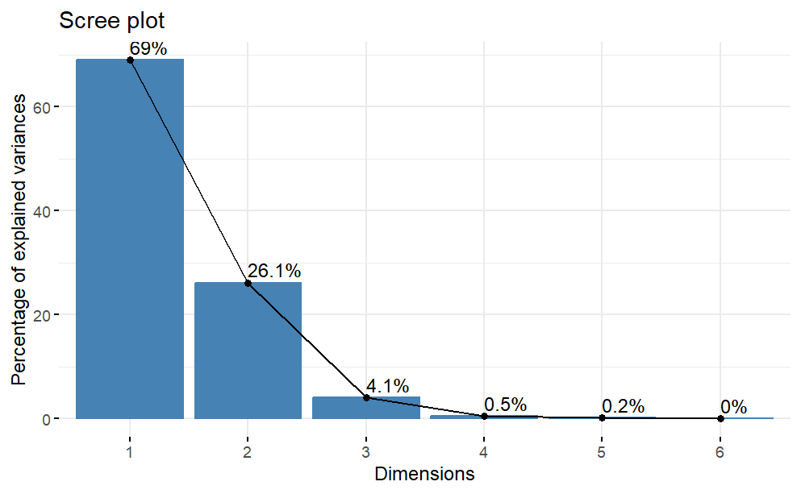

```r
# Scree plot: gráfico de sedimentacion
sed <- fviz_eig(pca, addlabels = T)
sed
```

Una vez que tenemos los componentes podemos observar como se relacionan con nuestras variables (columnas).

```r
# Matriz de carga
pca$loadings[,1:6]
```

```
               Comp.1     Comp.2      Comp.3     Comp.4      Comp.5
GMCSF       0.5401950  0.1853624  0.60935919  0.4378162  0.00448735
MCF7       -0.3444123  0.6343595 -0.15315531 -0.1149958 -0.18174968
T47D       -0.2646848  0.4364068  0.22722954  0.2914797 -0.48511389
MDA.MB.231 -0.5269264 -0.2997539 -0.07842722  0.7438543  0.19738342
UIVC1      -0.3274345  0.2770246  0.45565497 -0.2217181  0.72702775
UIVC4      -0.3669423 -0.4540736  0.58294021 -0.3281073 -0.40507020
               Comp.6
GMCSF       0.3328788
MCF7        0.6397301
T47D       -0.6062689
MDA.MB.231  0.1845696
UIVC1      -0.1751978
UIVC4       0.2182085
```

A través de un biplot podemos visualizar las similitudes y diferencias entre las muestras. Además, muestra el impacto de cada atributo en cada uno de los componentes principales.

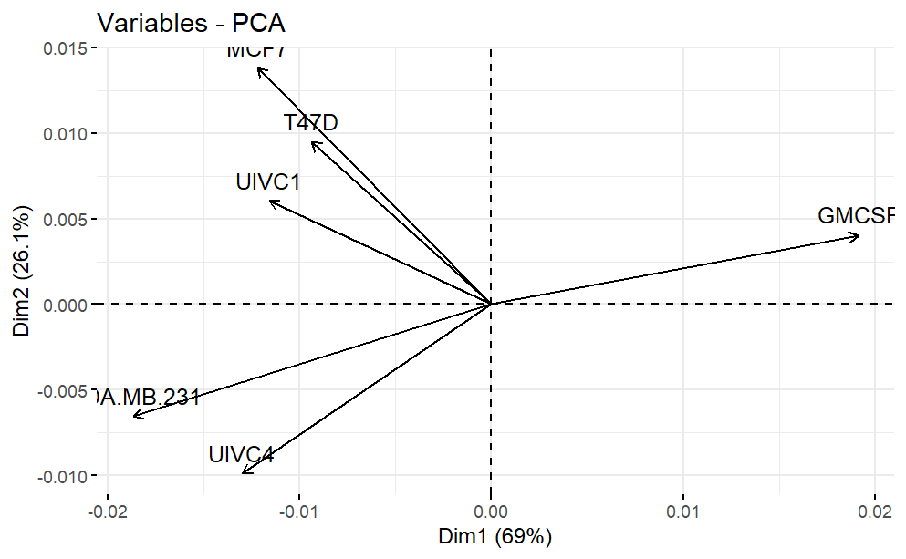

```r
# Graph of the variables
fviz_pca_var(pca, col.var = "black")
```

También podemos observar cuánto está representada cada variable en un componente determinado. El tamaño del valores proporcional a la representatividad de cada variable a los componentes:

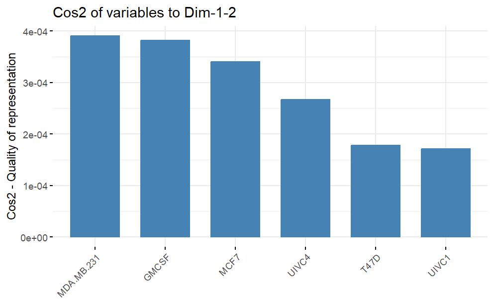

```r
# Representacion de cada variable en los componentes: las barras mas altas indican que esas
# variables contribuyen más en los componenetes indicados
cos <- fviz_cos2(pca, choice = "var", axes = 1:2)
cos
```

Los dos gráficos anteriores se pueden visualizar en un mismo gráfico, lo cual es más ilustrativo:

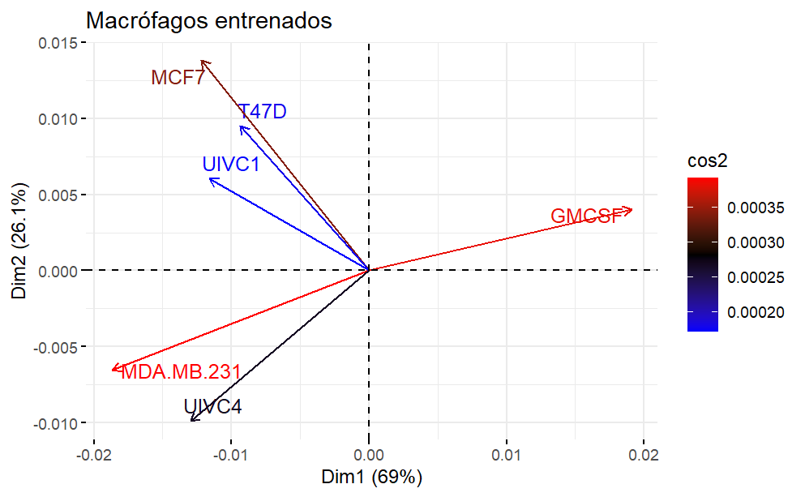

```r
# Combinacion del peso de los componentes y la influencia de las varibles en ellos
pcaf <- fviz_pca_var(pca, col.var = "cos2",
                     gradient.cols = c("blue", "black", "red"),
                     repel = T) + ggtitle("Macrófagos entrenados ")


pcaf
```

Finalmente, podemos guardar nuestro gráfico en el directorio de trabajo.

```r
#---- Guardar el grafico----
path = "D:/marval_windows/JR_MARVAL/programacion/ciencia_computacional_himfg/"

png(filename =paste (path, "pcaf_mediana_MACcoCC.png", sep = ""),
    res = 1800, height = 7, width = 7, units = "in")
pcaf
dev.off()
```

Referencia: [Principal Component Analysis in R Tutorial](https://www.datacamp.com/tutorial/pca-analysis-r)